# Characteristics of Different Democracy Measures

Xavier Marquez

2016-05-27

This vignette describes the temporal and spatial coverage of the democracy measures included in this package, notes their correlations, and documents any changes made to the original data sources.

# General Characteristics

```r
library(knitr)
library(QuickUDS)
library(dplyr)
library(reshape2)

democracy_long <- democracy %>%
        melt(id.vars = 1:15, na.rm=TRUE)

kable(democracy_long %>%
        group_by(variable) %>%
        summarise(distinct_countries = n_distinct(country_name),
                  distinct_years = n_distinct(year),
                  min_year = min(year),
                  max_year = max(year),
                  mean_year = mean(year),
                  num_values = n_distinct(value),
                  mean = mean(value),
                  median = median(value),
                  min_value = min(value),
                  max_value = max(value),
                  sd = sd(value)),
      digits = 2)
```

| variable | distinct_countries | distinct_years | min_year | max_year | mean_year | num_values | mean | median | min_value | max_value | sd |
| --- | --- | --- | --- | --- | --- | --- | --- | --- | --- | --- | --- |
| arat_pmm | 151 | 35 | 1948 | 1982 | 1967.70 | 77 | 73.20 | 69.00 | 29.00 | 109.00 | 18.91 |
| blm | 5 | 101 | 1900 | 2000 | 1950.00 | 3 | 0.25 | 0.00 | 0.00 | 1.00 | 0.36 |
| blm_pmm | 5 | 55 | 1946 | 2000 | 1973.00 | 3 | 0.36 | 0.00 | 0.00 | 1.00 | 0.41 |
| bmr_democracy | 212 | 211 | 1800 | 2010 | 1938.71 | 2 | 0.32 | 0.00 | 0.00 | 1.00 | 0.47 |
| bmr_democracy_omitteddata | 212 | 211 | 1800 | 2010 | 1938.89 | 2 | 0.32 | 0.00 | 0.00 | 1.00 | 0.47 |
| bnr | 200 | 93 | 1913 | 2005 | 1970.84 | 2 | 0.35 | 0.00 | 0.00 | 1.00 | 0.48 |
| bollen_pmm | 161 | 5 | 1950 | 1980 | 1965.48 | 348 | 55.46 | 53.59 | 0.00 | 100.00 | 33.70 |
| doorenspleet | 172 | 195 | 1800 | 1994 | 1921.29 | 2 | 1.18 | 1.00 | 1.00 | 2.00 | 0.38 |
| eiu | 176 | 16 | 1996 | 2014 | 2006.92 | 788 | 0.47 | 0.45 | 0.00 | 0.97 | 0.24 |
| exconst | 186 | 216 | 1800 | 2015 | 1938.89 | 10 | 0.09 | 3.00 | -88.00 | 7.00 | 17.29 |
| exrec | 186 | 216 | 1800 | 2015 | 1939.48 | 11 | 0.86 | 3.00 | -88.00 | 8.00 | 17.60 |
| freedomhouse | 200 | 43 | 1972 | 2015 | 1994.87 | 13 | 4.26 | 4.50 | 1.00 | 7.00 | 2.06 |
| freedomhouse_electoral | 196 | 27 | 1989 | 2015 | 2002.20 | 2 | 0.60 | 1.00 | 0.00 | 1.00 | 0.49 |
| freedomhouse_pmm | 198 | 37 | 1972 | 2008 | 1990.95 | 13 | 4.15 | 4.00 | 1.00 | 7.00 | 2.07 |
| gwf | 154 | 270 | 1741 | 2010 | 1969.92 | 2 | 1.43 | 1.00 | 1.00 | 2.00 | 0.49 |
| hadenius_pmm | 129 | 1 | 1988 | 1988 | 1988.00 | 51 | 4.51 | 3.10 | 0.00 | 10.00 | 3.56 |
| kailitz_binary | 198 | 66 | 1945 | 2010 | 1982.69 | 2 | 0.41 | 0.00 | 0.00 | 1.00 | 0.49 |
| kailitz_tri | 198 | 66 | 1945 | 2010 | 1982.69 | 3 | 0.99 | 1.00 | 0.00 | 2.00 | 0.91 |
| lied | 223 | 216 | 1800 | 2015 | 1938.91 | 7 | 2.78 | 3.00 | 0.00 | 6.00 | 2.35 |
| lied_accountable | 223 | 216 | 1800 | 2015 | 1938.91 | 3 | 0.94 | 1.00 | 0.00 | 2.00 | 0.87 |
| lied_electoral | 223 | 216 | 1800 | 2015 | 1938.91 | 3 | 1.38 | 2.00 | 0.00 | 2.00 | 0.85 |
| lied_inclusive | 223 | 216 | 1800 | 2015 | 1938.91 | 3 | 1.17 | 2.00 | 0.00 | 2.00 | 0.94 |
| magaloni_democ_binary | 172 | 244 | 1769 | 2012 | 1972.44 | 2 | 0.42 | 0.00 | 0.00 | 1.00 | 0.49 |
| magaloni_regime_tri | 172 | 244 | 1769 | 2012 | 1972.44 | 3 | 2.01 | 2.00 | 1.00 | 3.00 | 0.92 |
| mainwaring | 20 | 108 | 1900 | 2007 | 1953.60 | 3 | -0.32 | -1.00 | -1.00 | 1.00 | 0.84 |
| mainwaring_pmm | 18 | 62 | 1946 | 2007 | 1981.10 | 3 | 0.12 | 0.00 | -1.00 | 1.00 | 0.85 |
| munck_pmm | 18 | 19 | 1960 | 2005 | 1993.79 | 21 | 0.84 | 1.00 | 0.00 | 1.00 | 0.26 |
| pacl | 196 | 63 | 1946 | 2008 | 1981.94 | 2 | 0.44 | 0.00 | 0.00 | 1.00 | 0.50 |
| pacl_pmm | 196 | 63 | 1946 | 2008 | 1982.01 | 2 | 0.44 | 0.00 | 0.00 | 1.00 | 0.50 |
| PEPS1i | 175 | 204 | 1800 | 2003 | 1949.74 | 726 | -3.20 | -7.00 | -10.00 | 10.00 | 6.57 |
| PEPS1q | 176 | 204 | 1800 | 2003 | 1950.37 | 727 | -3.18 | -6.24 | -10.00 | 10.00 | 6.49 |
| PEPS1v | 177 | 204 | 1800 | 2003 | 1932.32 | 1866 | -2.87 | -4.00 | -10.00 | 10.00 | 5.66 |
| PEPS2i | 143 | 59 | 1945 | 2003 | 1981.28 | 843 | 3.72 | 5.00 | -9.59 | 10.00 | 4.39 |
| PEPS2q | 165 | 59 | 1945 | 2003 | 1978.99 | 856 | -1.13 | -1.46 | -10.00 | 10.00 | 6.91 |
| PEPS2v | 168 | 194 | 1810 | 2003 | 1937.77 | 2414 | -2.43 | -3.55 | -10.00 | 10.00 | 5.78 |
| pitf | 185 | 216 | 1800 | 2015 | 1939.20 | 5 | 2.42 | 2.00 | 1.00 | 5.00 | 1.48 |
| pitf_binary | 185 | 216 | 1800 | 2015 | 1939.20 | 2 | 1.36 | 1.00 | 1.00 | 2.00 | 0.48 |
| polcomp | 186 | 216 | 1800 | 2015 | 1939.20 | 13 | 1.30 | 6.00 | -88.00 | 10.00 | 17.76 |
| polity | 186 | 216 | 1800 | 2015 | 1938.89 | 24 | -4.08 | -3.00 | -88.00 | 10.00 | 17.67 |
| polity_pmm | 167 | 63 | 1946 | 2008 | 1980.85 | 21 | 0.13 | -1.00 | -10.00 | 10.00 | 7.50 |
| polity2 | 186 | 216 | 1800 | 2015 | 1938.91 | 21 | -0.60 | -3.00 | -10.00 | 10.00 | 7.07 |
| Polity3 | 181 | 204 | 1800 | 2003 | 1929.05 | 21 | -1.13 | -3.00 | -10.00 | 10.00 | 7.05 |
| polyarchy_contestation | 196 | 2 | 1985 | 2000 | 1993.11 | 9 | 5.82 | 6.00 | 1.00 | 9.00 | 2.90 |
| polyarchy_pmm | 194 | 2 | 1985 | 2000 | 1993.12 | 11 | 6.33 | 7.00 | 0.00 | 10.00 | 3.51 |
| polyarchy_reversed | 196 | 2 | 1985 | 2000 | 1993.11 | 11 | 6.35 | 7.00 | 0.00 | 10.00 | 3.52 |
| prc | 149 | 252 | 1747 | 1998 | 1937.00 | 4 | 2.00 | 1.00 | 1.00 | 4.00 | 1.30 |
| prc_notrans | 149 | 252 | 1747 | 1998 | 1936.50 | 3 | 2.00 | 1.00 | 1.00 | 4.00 | 1.31 |
| prc_pmm | 148 | 53 | 1946 | 1998 | 1974.83 | 4 | 2.15 | 1.00 | 1.00 | 4.00 | 1.37 |
| przeworski | 197 | 221 | 1788 | 2008 | 1950.24 | 4 | 1.79 | 2.00 | 0.00 | 3.00 | 0.81 |
| svolik | 198 | 88 | 1921 | 2008 | 1980.99 | 2 | 1.44 | 1.00 | 1.00 | 2.00 | 0.50 |
| ulfelder | 167 | 56 | 1955 | 2010 | 1984.84 | 2 | 0.41 | 0.00 | 0.00 | 1.00 | 0.49 |
| utip_dichotomous | 152 | 44 | 1963 | 2006 | 1984.47 | 2 | 0.52 | 1.00 | 0.00 | 1.00 | 0.50 |
| utip_dichotomous_strict | 152 | 44 | 1963 | 2006 | 1984.47 | 2 | 0.48 | 0.00 | 0.00 | 1.00 | 0.50 |
| utip_trichotomous | 152 | 44 | 1963 | 2006 | 1984.47 | 3 | 0.99 | 1.00 | 0.00 | 2.00 | 0.98 |
| v2x_api | 173 | 116 | 1900 | 2015 | 1960.74 | 9320 | 0.47 | 0.41 | 0.02 | 0.98 | 0.31 |
| v2x_delibdem | 172 | 116 | 1900 | 2015 | 1960.75 | 9884 | 0.21 | 0.07 | 0.00 | 0.93 | 0.27 |
| v2x_egaldem | 173 | 116 | 1900 | 2015 | 1960.74 | 10212 | 0.25 | 0.15 | 0.01 | 0.92 | 0.25 |
| v2x_libdem | 173 | 116 | 1900 | 2015 | 1960.74 | 10662 | 0.26 | 0.15 | 0.01 | 0.93 | 0.25 |
| v2x_mpi | 173 | 116 | 1900 | 2015 | 1960.74 | 6114 | 0.18 | 0.00 | 0.00 | 0.93 | 0.28 |
| v2x_partipdem | 173 | 116 | 1900 | 2015 | 1960.72 | 9949 | 0.20 | 0.11 | 0.00 | 0.84 | 0.21 |
| v2x_polyarchy | 173 | 116 | 1900 | 2015 | 1960.74 | 9320 | 0.32 | 0.21 | 0.01 | 0.96 | 0.28 |
| vanhanen_competition | 193 | 203 | 1810 | 2012 | 1947.43 | 694 | 25.22 | 20.00 | 0.00 | 70.00 | 25.17 |
| vanhanen_democratization | 193 | 203 | 1810 | 2012 | 1947.43 | 445 | 8.43 | 1.10 | 0.00 | 49.00 | 11.68 |
| vanhanen_participation | 193 | 203 | 1810 | 2012 | 1947.43 | 760 | 21.10 | 14.00 | 0.00 | 71.00 | 21.88 |
| vanhanen_pmm | 192 | 63 | 1946 | 2008 | 1981.71 | 439 | 11.31 | 5.90 | 0.00 | 49.00 | 12.67 |
| wahman_teorell_hadenius | 193 | 39 | 1972 | 2010 | 1991.93 | 2 | 0.42 | 0.00 | 0.00 | 1.00 | 0.49 |

# Arat

This is the dataset described in Arat 1991; the actual values are taken from Pemstein, Meserve, and Melton 2013 (the replication data for Pemstein, Meserve, and Melton 2010).

## Coverage

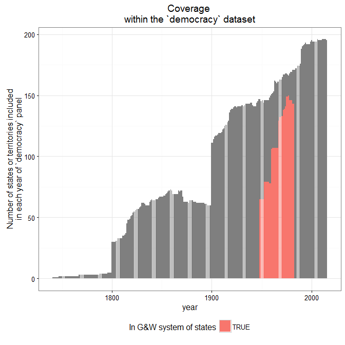

```r
library(ggplot2)

panel <- democracy %>% select(country_name,year) %>% distinct()

temporal_coverage <- function(data) {
  data <- left_join(panel,data)

  data <- data %>%
    group_by(year, add=TRUE) %>%
    count(year,in_system)

  ggplot(data =  data, aes(x=year,fill = in_system, y = n)) +
    geom_bar(stat = "identity") +
    theme_bw() +
    theme(legend.position = "bottom") +
    labs(fill = "In G&W system of states",
         y = "Number of states or territories included\nin each year of `democracy` panel") +
    ggtitle("Coverage \nwithin the `democracy` dataset")
}

library(rworldmap)
world <- getMap()
world <- fortify(world)
spatial_coverage <- function(data) {
  ggplot() +
    geom_path(data = world, aes(x=long,y=lat,group=group)) +
    theme_bw() +
    theme(legend.position = "bottom") +
    geom_count(data = data, aes(x=lon,y=lat,color = in_system)) +
    labs(color = "In G&W system of states", y = "", x = "", size = "Number of country-years") +
    ggtitle("Spatial coverage")
}

data <- democracy_long %>%
  filter(variable == "arat_pmm")

temporal_coverage(data)
```

```r
spatial_coverage(data)
```

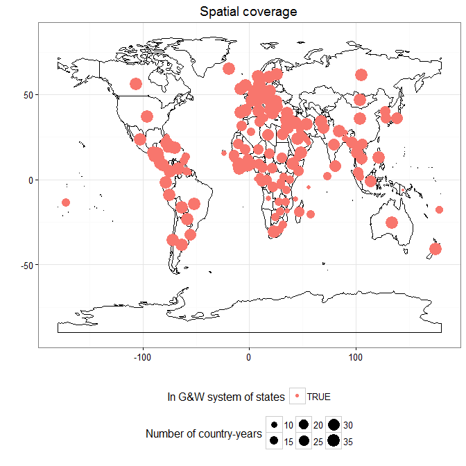

## Distribution

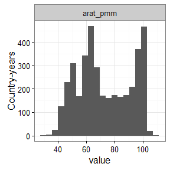

```r
ggplot(data = data) +
  geom_histogram(aes(x=value),bins=20) +
  theme_bw() +
  theme(legend.position = "bottom") +
  labs(y = "Country-years") +
  facet_wrap(~variable, ncol=2)
```

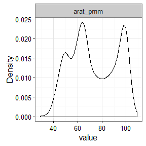

```r
ggplot(data = data) +
  geom_density(aes(x=value)) +
  theme_bw() +
  theme(legend.position = "bottom") +
  labs(y = "Density") +
  facet_wrap(~variable, ncol=2)
```

# BLM

This is the dataset described in Bowman, Lehoucq, and Mahoney 2005.

## Coverage

```r
data <- democracy_long %>% filter(variable == "blm")

temporal_coverage(data)
```

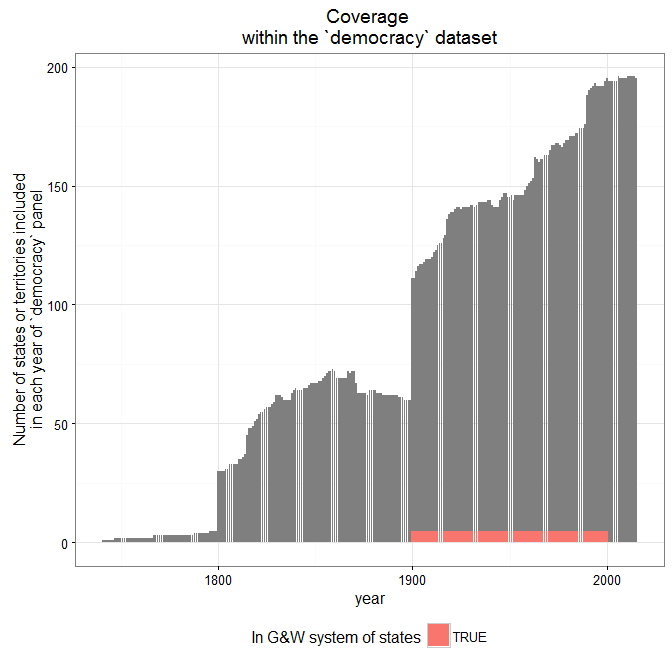

```r
spatial_coverage(data)
```

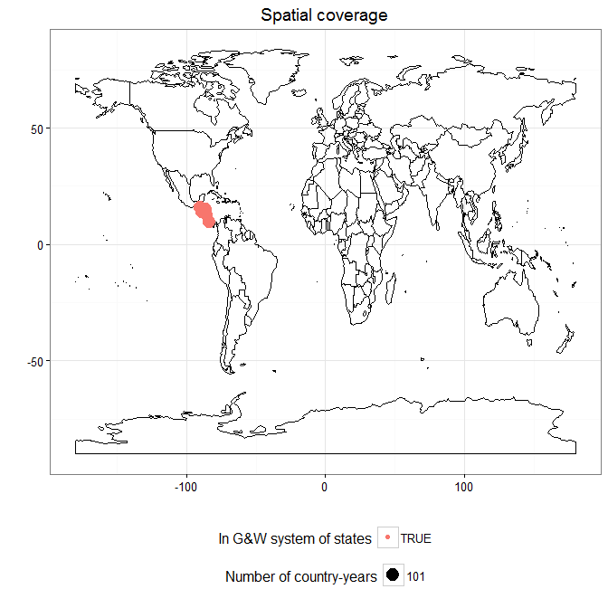

## Distribution

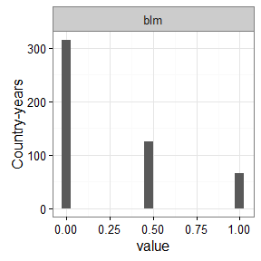

```r
ggplot(data = data) +
  geom_histogram(aes(x=value),bins=20) +
  theme_bw() +
  theme(legend.position = "bottom") +
  labs(y = "Country-years") +
  facet_wrap(~variable, ncol=2)
```

# BMR

This is the dataset described in Boix, Miller, and Rosato 2012.

## Coverage

```r
data <- democracy_long %>% filter(variable == "bmr_democracy")

temporal_coverage(data)
```

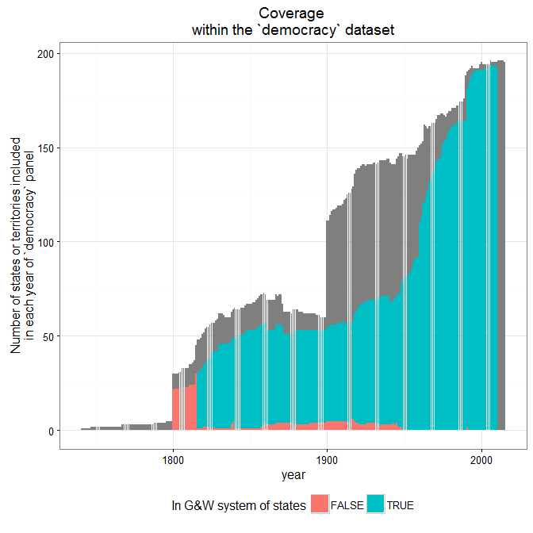

```r
spatial_coverage(data)
```

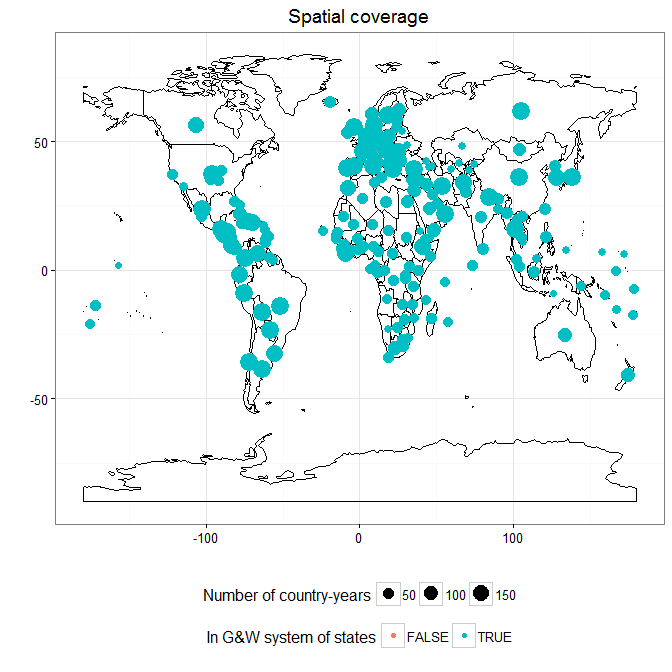

## Distribution

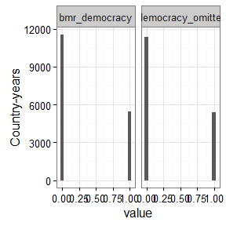

```r
data <- democracy_long %>% filter(variable %in% c("bmr_democracy","bmr_democracy_omitteddata"))

ggplot(data = data) +
  geom_histogram(aes(x=value),bins=20) +
  theme_bw() +
  theme(legend.position = "bottom") +
  labs(y = "Country-years") +
  facet_wrap(~variable, ncol=2)
```

# BNR

This is the dataset described in Bernhardt, Nordstrom, and Reenock 2001. The original dataset only counts periods of democracy in the period 1913-2005, since it is designed for event history analysis. To put it in country-year format, this package assumes that country-years in independent states between 1913 and 2005 are to be counted as non-democratic if they are not explicitly said to be democratic by BNR. (Country-years are considered to be independent if the state is not a microstate and appears in Gleditasch and Ward’s [1999] panel of indepdent states for the period).

## Coverage

```r
data <- democracy_long %>% filter(variable == "bnr")

temporal_coverage(data)
```

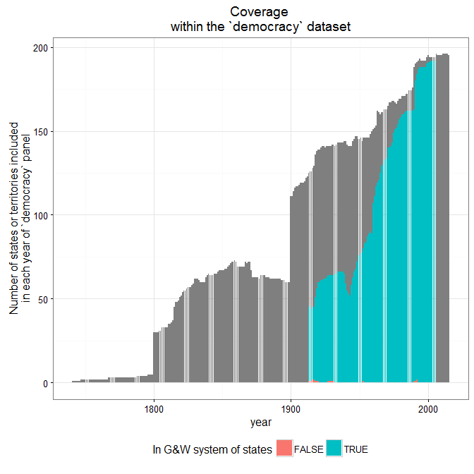

```r
spatial_coverage(data)
```

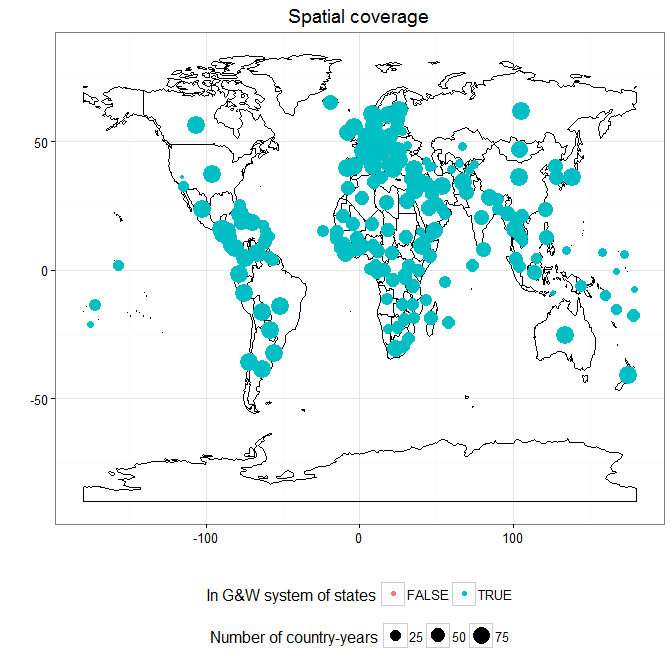

## Distribution

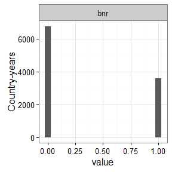

```r
ggplot(data = data) +
  geom_histogram(aes(x=value),bins=20) +
  theme_bw() +
  theme(legend.position = "bottom") +
  labs(y = "Country-years") +
  facet_wrap(~variable, ncol=2)
```

# Bollen

This is the dataset described in Bollen 2001. The actual values are taken from Pemstein, Meserve, and Melton’s replication data for their article (Pemstein, Meserve, and Melton 2013).

## Coverage

```r
data <- democracy_long %>% filter(variable == "bollen_pmm")

temporal_coverage(data)
```

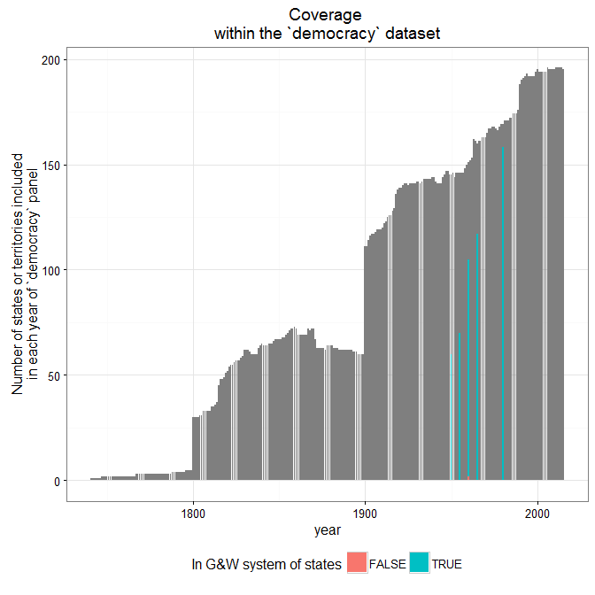

```r
spatial_coverage(data)
```

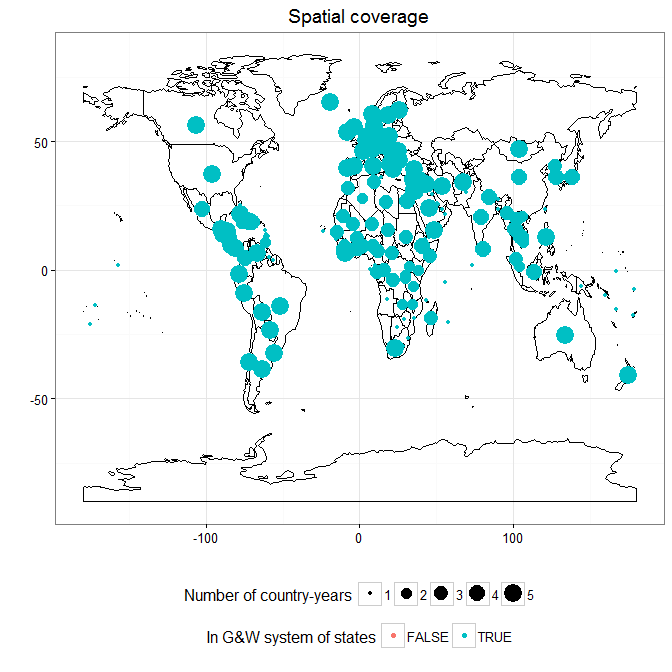

## Distribution

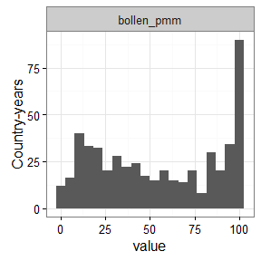

```r
ggplot(data = data) +
  geom_histogram(aes(x=value),bins=20) +
  theme_bw() +
  theme(legend.position = "bottom") +
  labs(y = "Country-years") +
  facet_wrap(~variable, ncol=2)
```

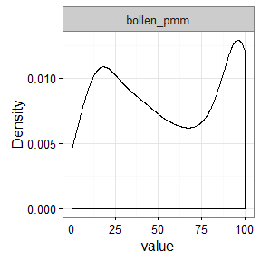

```r
ggplot(data = data) +
  geom_density(aes(x=value)) +
  theme_bw() +
  theme(legend.position = "bottom") +
  labs(y = "Density") +
  facet_wrap(~variable, ncol=2)
```

# Doorenspleet

This is the dataset described in Doorenspleet 2000.

## Coverage

```r
data <- democracy_long %>% filter(variable == "doorenspleet")

temporal_coverage(data)
```

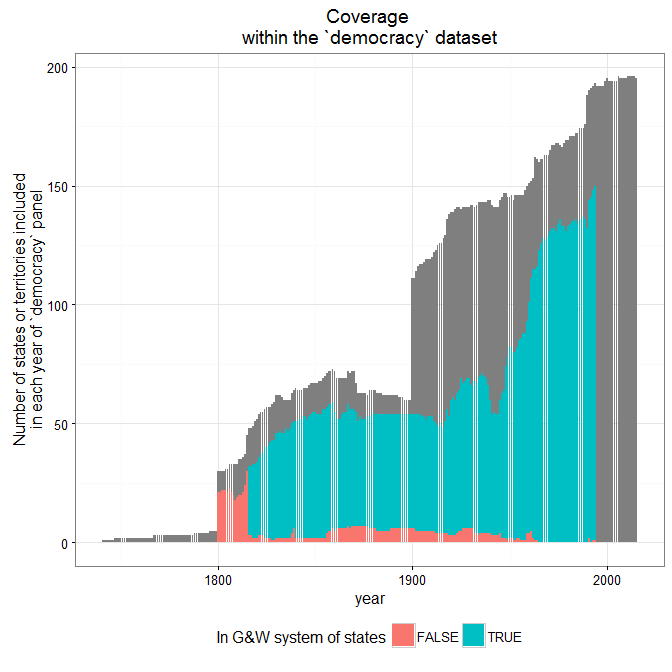

```r
spatial_coverage(data)
```

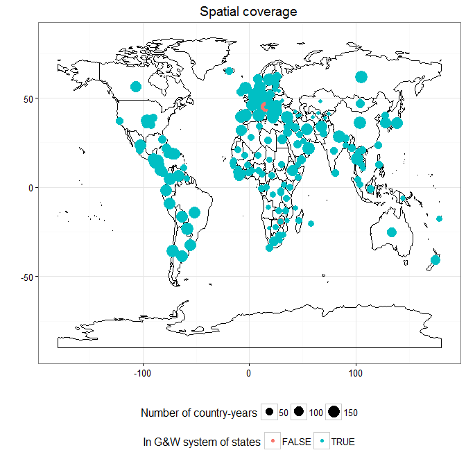

## Distribution

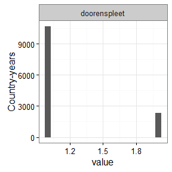

```r
ggplot(data = data) +
  geom_histogram(aes(x=value),bins=20) +
  theme_bw() +
  theme(legend.position = "bottom") +
  labs(y = "Country-years") +
  facet_wrap(~variable, ncol=2)
```

# EIU

This contains the Economist Intelligence Unit’s index of democracy (EIU 2012). The actual data is taken from the World Bank’s Governance Indicators (http://www.govindicators.org)

## Coverage

```r
data <- democracy_long %>% filter(variable == "eiu")

temporal_coverage(data)
```

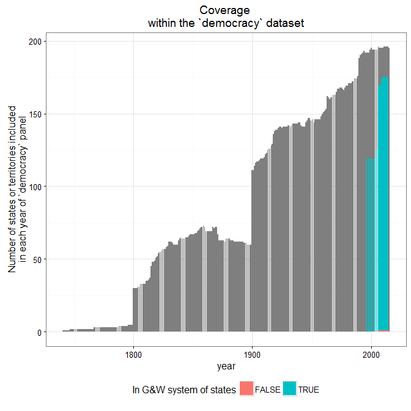

```r
spatial_coverage(data)
```

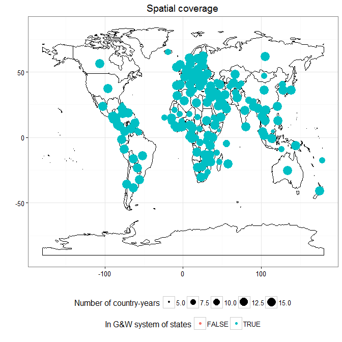

## Distribution

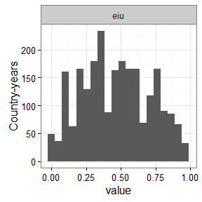

```r
ggplot(data = data) +
  geom_histogram(aes(x=value),bins=20) +
  theme_bw() +
  theme(legend.position = "bottom") +
  labs(y = "Country-years") +
  facet_wrap(~variable, ncol=2)
```

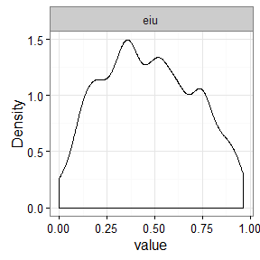

```r
ggplot(data = data) +
  geom_density(aes(x=value)) +
  theme_bw() +
  theme(legend.position = "bottom") +
  labs(y = "Density") +
  facet_wrap(~variable, ncol=2)
```

# Freedom House (Freedom in the World)

This is the Freedom in the World Index, to 2015 (Freedom House 2016). Some non-independent territories have been excluded from the original data.

## Coverage

```r
data <- democracy_long %>% filter(variable %in% c("freedomhouse"))

temporal_coverage(data)
```

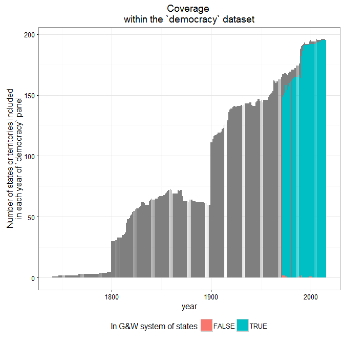

```r
spatial_coverage(data)
```

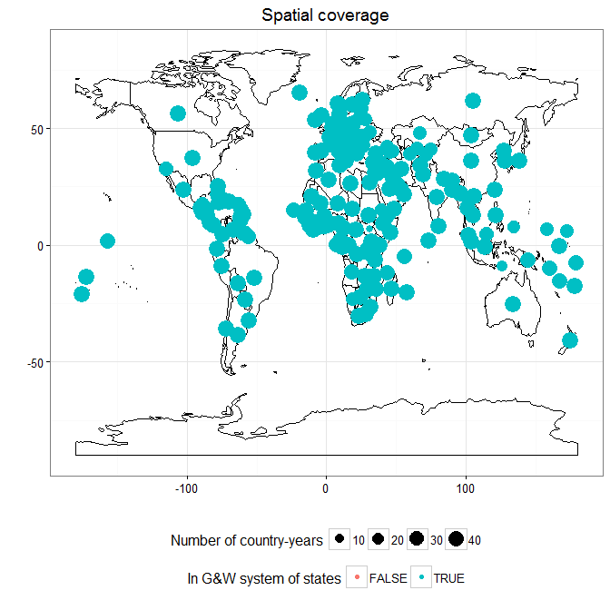

## Distribution

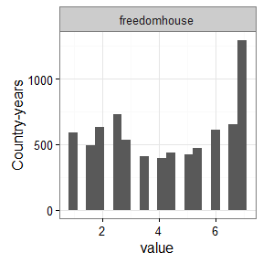

```r
ggplot(data = data) +
  geom_histogram(aes(x=value),bins=20) +
  theme_bw() +
  theme(legend.position = "bottom") +
  labs(y = "Country-years") +
  facet_wrap(~variable, ncol=2)
```

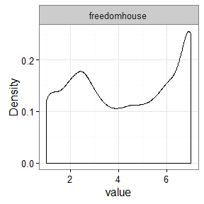

```r
ggplot(data = data) +
  geom_density(aes(x=value)) +
  theme_bw() +
  theme(legend.position = "bottom") +
  labs(y = "Density") +
  facet_wrap(~variable, ncol=2)
```

# Freedom House (Electoral Democracies)

This is Freedom House’s list of electoral democracies, to 2015 (Freedom House 2016). Some non-independent territories have been excluded from the original data.

## Coverage

```r
data <- democracy_long %>% filter(variable == "freedomhouse_electoral")

temporal_coverage(data)
```

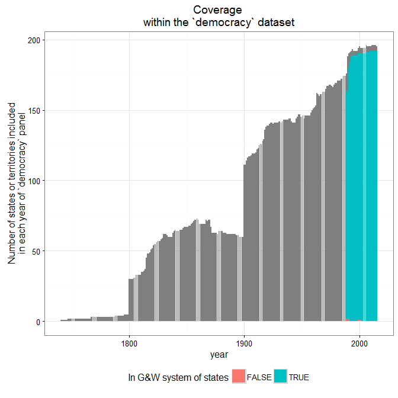

```r
spatial_coverage(data)
```

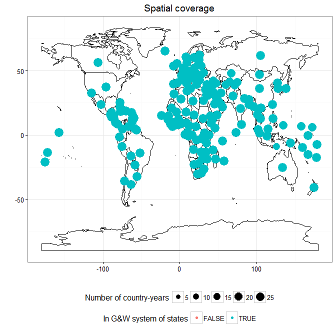

## Distribution

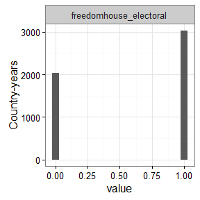

```r
ggplot(data = data) +
  geom_histogram(aes(x=value),bins=20) +
  theme_bw() +
  theme(legend.position = "bottom") +
  labs(y = "Country-years") +
  facet_wrap(~variable, ncol=2)
```

# GWF (Geddes, Wright, and Frantz)

This is a measure of democracy/non-democracy derived from the dataset described in Geddes, Wright, and Frantz 2014. The original data has been extended beyond 1945 by reconciling the information contained in the original dataset’s `gwf_startdate`, `gwf_spell`, and `gwf_casename` variables, which encode the start year of each democratic and non-democratic regime (sometimes going back to the 18th century).

## Coverage

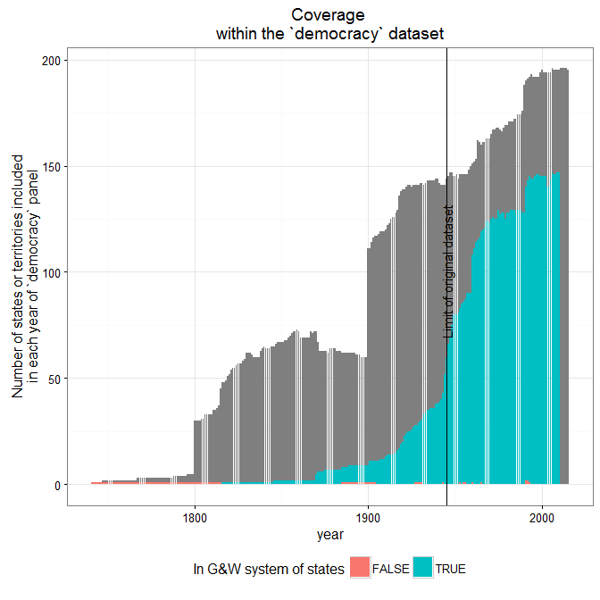

```r
data <- democracy_long %>% filter(variable == "gwf")

temporal_coverage(data) +
  geom_vline(xintercept = 1945) +
  annotate("text", label = "Limit of original dataset", x = 1945,y = 100, angle=90)
```

```r
spatial_coverage(data)
```

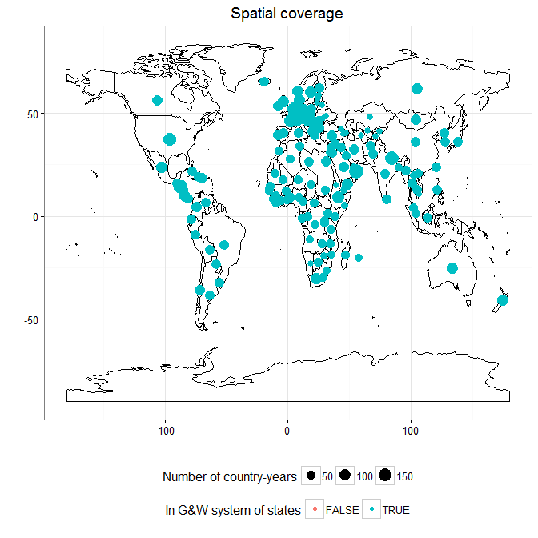

## Distribution

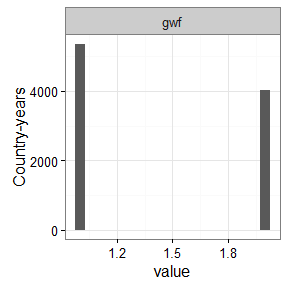

```r
ggplot(data = data) +
  geom_histogram(aes(x=value),bins=20) +
  theme_bw() +
  theme(legend.position = "bottom") +
  labs(y = "Country-years") +
  facet_wrap(~variable, ncol=2)
```

# Hadenius

This is the dataset in Hadenius 1992. Actual values taken from Pemstein, Meserve, and Melton 2013.

## Coverage

```r
data <- democracy_long %>% filter(variable == "hadenius_pmm")

temporal_coverage(data)
```

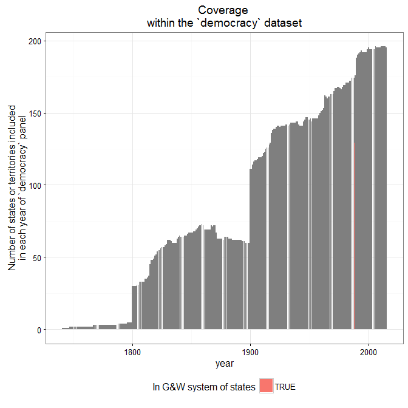

```r
spatial_coverage(data)
```

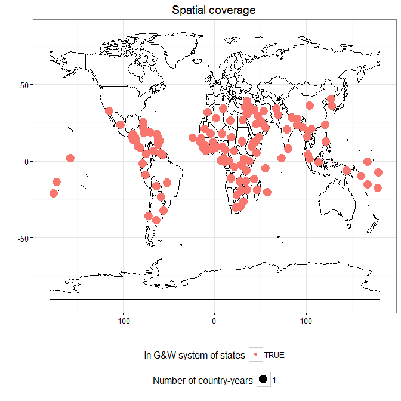

## Distribution

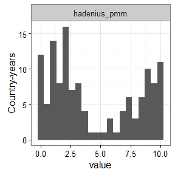

```r
ggplot(data = data) +
  geom_histogram(aes(x=value),bins=20) +
  theme_bw() +
  theme(legend.position = "bottom") +
  labs(y = "Country-years") +
  facet_wrap(~variable, ncol=2)
```

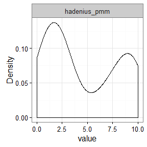

```r
ggplot(data = data) +
  geom_density(aes(x=value)) +
  theme_bw() +
  theme(legend.position = "bottom") +
  labs(y = "Density") +
  facet_wrap(~variable, ncol=2)
```

# Kailitz

The dataset described in Kailitz 2013.

## Coverage

```r
data <- democracy_long %>% filter(variable == "kailitz_binary")

temporal_coverage(data)
```

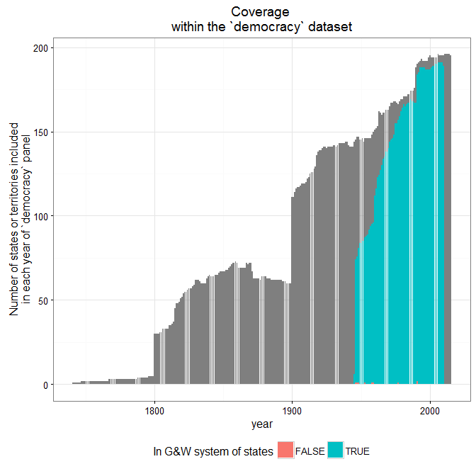

```r
spatial_coverage(data)
```

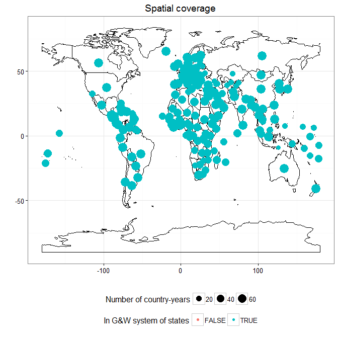

## Distribution

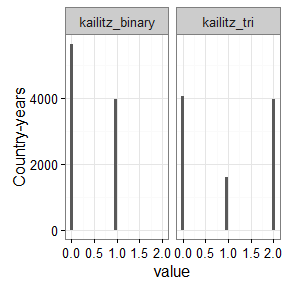

```r
data <- democracy_long %>% filter(variable %in% c("kailitz_binary","kailitz_tri"))

ggplot(data = data) +
  geom_histogram(aes(x=value)) +
  theme_bw() +
  theme(legend.position = "bottom") +
  labs(y = "Country-years") +
  facet_wrap(~variable, ncol=2)
```

## Index construction and known problems

Note that 316 of the country-years in the Kailitz dataset are classified with more than one regime type.

```r
kable(kailitz.yearly %>%
        count(multiple_regimes = grepl("-",combined_regime)))
```

| multiple_regimes | n |
| --- | --- |
| FALSE | 9290 |
| TRUE | 316 |

```r
kable(kailitz.yearly %>%
        filter(grepl("-",combined_regime)) %>%
        group_by(country_name) %>%
        arrange(country_name,year) %>%
        group_by(combined_regime, add=TRUE) %>%
        summarise(min = min(year), max = max(year), n = n()))
```

| country_name | combined_regime | min | max | n |
| --- | --- | --- | --- | --- |
| Afghanistan | Electoral Autocracy-Personalist Autocracy | 2010 | 2010 | 1 |
| Algeria | Electoral Autocracy-One party Autocracy | 1989 | 1991 | 3 |
| Angola | Electoral Autocracy-State Failure or Occupation | 2010 | 2010 | 1 |
| Benin | Electoral Autocracy-Personalist Autocracy | 1960 | 1962 | 3 |
| Benin | Military Autocracy-Personalist Autocracy | 1965 | 1974 | 8 |
| Benin | Personalist Autocracy-Transition | 1963 | 1971 | 4 |
| Burundi | Electoral Autocracy-State Failure or Occupation | 1993 | 1995 | 3 |
| Burundi | One party Autocracy-Personalist Autocracy | 1982 | 1983 | 2 |
| Cambodia (Kampuchea) | Communist Ideocracy-State Failure or Occupation | 1981 | 1990 | 10 |
| Central African Republic | Electoral Autocracy-One party Autocracy | 1991 | 1992 | 2 |
| Colombia | Electoral Autocracy-Liberal Democracy | 1946 | 1947 | 2 |
| Colombia | State Failure or Occupation-Transition | 1948 | 1952 | 5 |
| Cuba | Electoral Autocracy-Liberal Democracy | 1946 | 1951 | 6 |
| Ecuador | Electoral Autocracy-Personalist Autocracy | 1970 | 1971 | 2 |
| Ecuador | Electoral Autocracy-Transition | 2000 | 2001 | 2 |
| Guinea-Bissau | Military Autocracy-Personalist Autocracy | 1980 | 1983 | 4 |
| Guinea-Bissau | Military Autocracy-Transition | 2004 | 2004 | 1 |
| Haiti | Electoral Autocracy-Transition | 1946 | 1947 | 2 |
| Honduras | Electoral Autocracy-Liberal Democracy | 1957 | 1962 | 6 |
| Indonesia | Personalist Autocracy-Transition | 1952 | 1967 | 12 |
| Kuwait | Monarchy-State Failure or Occupation | 1990 | 1990 | 1 |
| Lebanon | State Failure or Occupation-Transition | 2000 | 2001 | 2 |
| Lesotho | Electoral Autocracy-State Failure or Occupation | 1998 | 1999 | 2 |
| Lesotho | Electoral Autocracy-Transition | 2000 | 2001 | 2 |
| Liberia | Personalist Autocracy-State Failure or Occupation | 1990 | 1990 | 1 |
| Madagascar (Malagasy) | Military Autocracy-Personalist Autocracy | 1972 | 1974 | 3 |
| Madagascar (Malagasy) | Personalist Autocracy-Transition | 1975 | 1975 | 1 |
| Mauritania | Electoral Autocracy-Military Autocracy | 2008 | 2008 | 1 |
| Mozambique | Personalist Autocracy-Transition | 1991 | 1993 | 3 |
| Nicaragua | Communist Ideocracy-Electoral Autocracy | 1984 | 1989 | 6 |
| Nicaragua | Communist Ideocracy-State Failure or Occupation | 1980 | 1981 | 2 |
| Nicaragua | Communist Ideocracy-Transition | 1982 | 1983 | 2 |
| Nicaragua | Electoral Autocracy-Personalist Autocracy | 1972 | 1972 | 1 |
| Nicaragua | Military Autocracy-Personalist Autocracy | 1973 | 1973 | 1 |
| Niger | Electoral Autocracy-Liberal Democracy | 2000 | 2010 | 11 |
| Peru | Electoral Autocracy-Liberal Democracy | 1963 | 1967 | 5 |
| Philippines | Electoral Autocracy-Liberal Democracy | 1946 | 1971 | 26 |
| Philippines | Liberal Democracy-Personalist Autocracy | 1994 | 2002 | 9 |
| Portugal | Military Autocracy-Transition | 1974 | 1975 | 2 |
| Seychelles | Electoral Autocracy-Liberal Democracy | 2007 | 2010 | 4 |
| Seychelles | Liberal Democracy-Transition | 1976 | 1976 | 1 |
| Somalia | Liberal Democracy-Transition | 1960 | 1968 | 9 |
| Somalia | Military Autocracy-Personalist Autocracy | 1969 | 1990 | 22 |
| Somalia | Military Autocracy-State Failure or Occupation | 1991 | 1991 | 1 |
| Spain | Military Autocracy-One party Autocracy-Personalist Autocracy | 1946 | 1974 | 29 |
| Sri Lanka (Ceylon) | Electoral Autocracy-Liberal Democracy | 1960 | 2010 | 51 |
| Sri Lanka (Ceylon) | Electoral Autocracy-Transition | 1948 | 1959 | 12 |
| Syria | One party Autocracy-Personalist Autocracy | 2000 | 2010 | 11 |
| Tunisia | One party Autocracy-Personalist Autocracy | 1975 | 1978 | 4 |
| Venezuela | Military Autocracy-Personalist Autocracy | 1948 | 1957 | 10 |
| Yemen (Arab Republic of Yemen) | Monarchy-Transition | 1946 | 1947 | 2 |

The following are especially troublesome, since the multiple categories do not make sense:

```r
kable(kailitz.yearly %>%
        filter(grepl("-",combined_regime)) %>%
        group_by(country_name) %>%
        arrange(country_name,year) %>%
        group_by(combined_regime, add=TRUE) %>%
        summarise(min = min(year), max = max(year), n = n()) %>%
        filter(grepl("democracy",combined_regime, ignore.case=TRUE)))
```

| country_name | combined_regime | min | max | n |
| --- | --- | --- | --- | --- |
| Colombia | Electoral Autocracy-Liberal Democracy | 1946 | 1947 | 2 |
| Cuba | Electoral Autocracy-Liberal Democracy | 1946 | 1951 | 6 |
| Honduras | Electoral Autocracy-Liberal Democracy | 1957 | 1962 | 6 |
| Niger | Electoral Autocracy-Liberal Democracy | 2000 | 2010 | 11 |
| Peru | Electoral Autocracy-Liberal Democracy | 1963 | 1967 | 5 |
| Philippines | Electoral Autocracy-Liberal Democracy | 1946 | 1971 | 26 |
| Philippines | Liberal Democracy-Personalist Autocracy | 1994 | 2002 | 9 |
| Seychelles | Electoral Autocracy-Liberal Democracy | 2007 | 2010 | 4 |
| Seychelles | Liberal Democracy-Transition | 1976 | 1976 | 1 |
| Somalia | Liberal Democracy-Transition | 1960 | 1968 | 9 |
| Sri Lanka (Ceylon) | Electoral Autocracy-Liberal Democracy | 1960 | 2010 | 51 |

I have constructed the index to classify a country as “democratic” only if it is not also classified as a non-democratic regime as well. Here are the index counts for each regime type:

```r
kable(kailitz.yearly %>%
        count(kailitz_binary,kailitz_tri,combined_regime))
```

| kailitz_binary | kailitz_tri | combined_regime | n |
| --- | --- | --- | --- |
| 0 | 0 | Communist Ideocracy | 788 |
| 0 | 0 | Communist Ideocracy-Electoral Autocracy | 6 |
| 0 | 0 | Communist Ideocracy-State Failure or Occupation | 12 |
| 0 | 0 | Communist Ideocracy-Transition | 2 |
| 0 | 0 | Electoral Autocracy-Military Autocracy | 1 |
| 0 | 0 | Electoral Autocracy-One party Autocracy | 5 |
| 0 | 0 | Electoral Autocracy-Personalist Autocracy | 7 |
| 0 | 0 | Electoral Autocracy-State Failure or Occupation | 6 |
| 0 | 0 | Electoral Autocracy-Transition | 18 |
| 0 | 0 | Liberal Democracy-Personalist Autocracy | 9 |
| 0 | 0 | Liberal Democracy-Transition | 10 |
| 0 | 0 | Military Autocracy | 570 |
| 0 | 0 | Military Autocracy-One party Autocracy-Personalist Autocracy | 29 |
| 0 | 0 | Military Autocracy-Personalist Autocracy | 48 |
| 0 | 0 | Military Autocracy-State Failure or Occupation | 1 |
| 0 | 0 | Military Autocracy-Transition | 3 |
| 0 | 0 | Monarchy | 987 |
| 0 | 0 | Monarchy-State Failure or Occupation | 1 |
| 0 | 0 | Monarchy-Transition | 2 |
| 0 | 0 | One party Autocracy | 486 |
| 0 | 0 | One party Autocracy-Personalist Autocracy | 17 |
| 0 | 0 | Personalist Autocracy | 463 |
| 0 | 0 | Personalist Autocracy-State Failure or Occupation | 1 |
| 0 | 0 | Personalist Autocracy-Transition | 20 |
| 0 | 0 | State Failure or Occupation | 245 |
| 0 | 0 | State Failure or Occupation-Transition | 7 |
| 0 | 0 | Transition | 319 |
| 0 | 1 | Electoral Autocracy | 1477 |
| 0 | 1 | Electoral Autocracy-Liberal Democracy | 111 |
| 1 | 2 | Liberal Democracy | 3955 |

# LIED

This is the Lexical Index of Democracy described in Skaaning, Gerring, and Bartusevicius 2015 (version 3, updated to 2015).

## Coverage

```r
data <- democracy_long %>% filter(variable == "lied")

temporal_coverage(data)
```

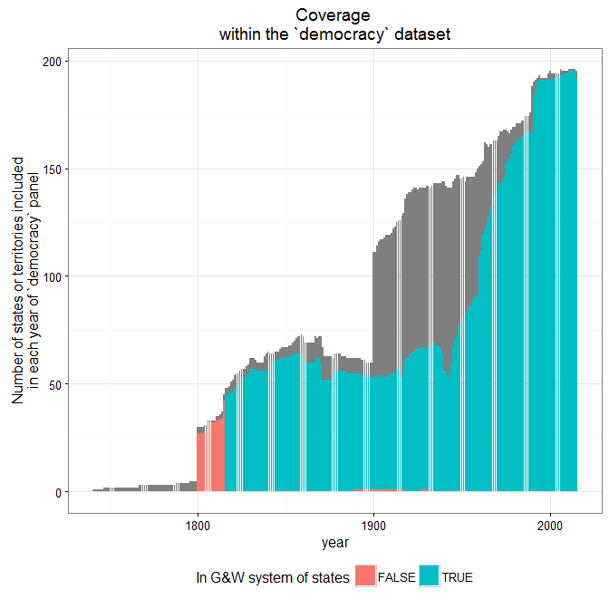

```r
spatial_coverage(data)
```

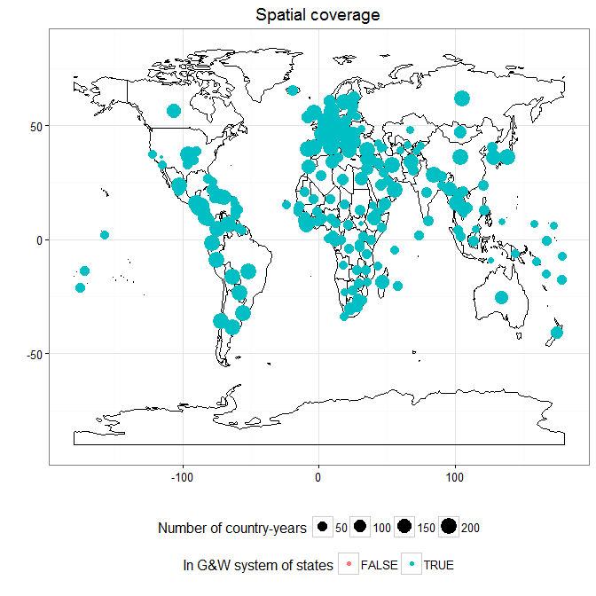

## Distribution

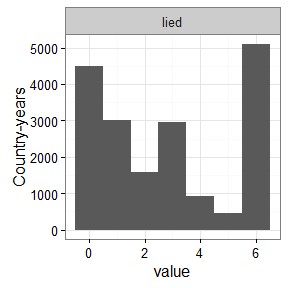

```r
ggplot(data = data) +
  geom_histogram(aes(x=value),binwidth=1) +
  theme_bw() +
  theme(legend.position = "bottom") +
  labs(y = "Country-years") +
  facet_wrap(~variable, ncol=2)
```

# Magaloni

## Coverage

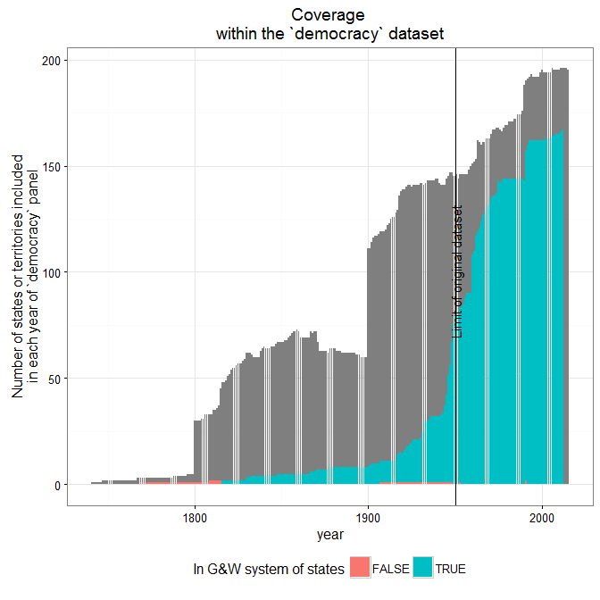

```r
data <- democracy_long %>% filter(variable == "magaloni_democ_binary")

temporal_coverage(data) +
  geom_vline(xintercept = 1950) +
  annotate("text", label = "Limit of original dataset", x = 1950,y = 100, angle=90)
```

```r
spatial_coverage(data)
```

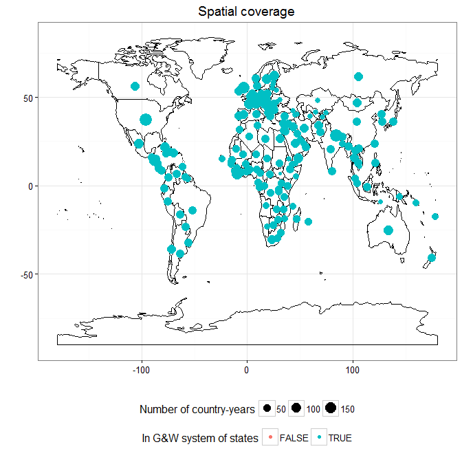

## Distribution

One change has been made (Pakistan 1971/1972 appears to have been misclassified as a democracy).

Note `magaloni_regime_tri` identifies as “hybrid” (middle level) all multiparty autocracies.

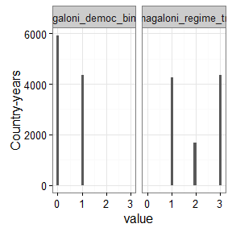

```r
data <- democracy_long %>% filter(variable %in% c("magaloni_democ_binary","magaloni_regime_tri"))

ggplot(data = data) +
  geom_histogram(aes(x=value)) +
  theme_bw() +
  theme(legend.position = "bottom") +
  labs(y = "Country-years") +
  facet_wrap(~variable, ncol=2)
```

# Mainwaring

This is the dataset in Mainwaring, Brinks, and Perez Linan 2008.

## Coverage

```r
data <- democracy_long %>% filter(variable == "mainwaring")

temporal_coverage(data)
```

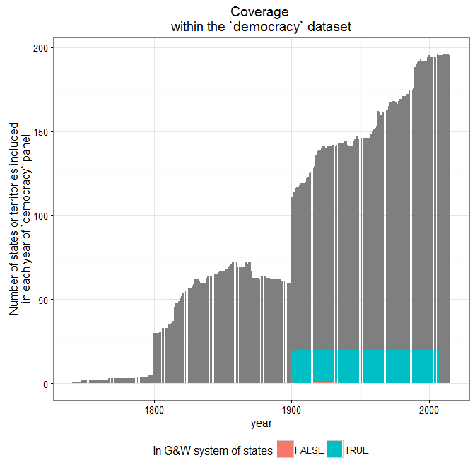

```r
spatial_coverage(data)
```

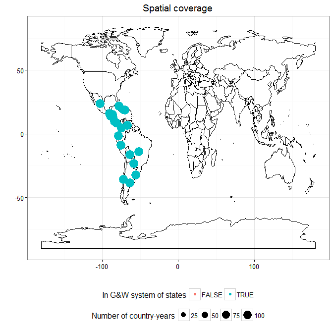

## Distribution

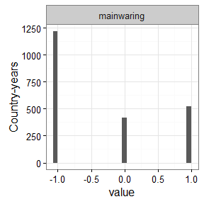

```r
ggplot(data = data) +
  geom_histogram(aes(x=value)) +
  theme_bw() +
  theme(legend.position = "bottom") +
  labs(y = "Country-years") +
  facet_wrap(~variable, ncol=2)
```

# Munck

This is the dataset in Munck 2009. Taken from Pemstein, Meserve, and Melton 2013.

## Coverage

```r
data <- democracy_long %>% filter(variable == "munck_pmm")

temporal_coverage(data)
```

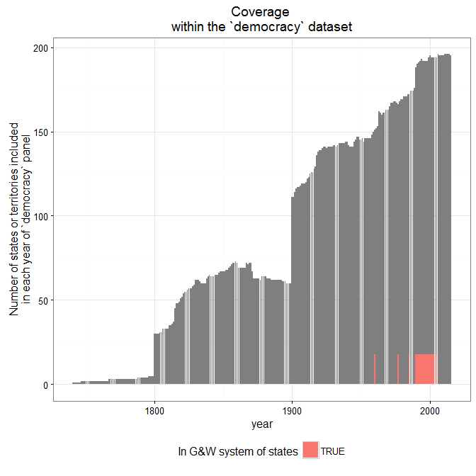

```r
spatial_coverage(data)
```

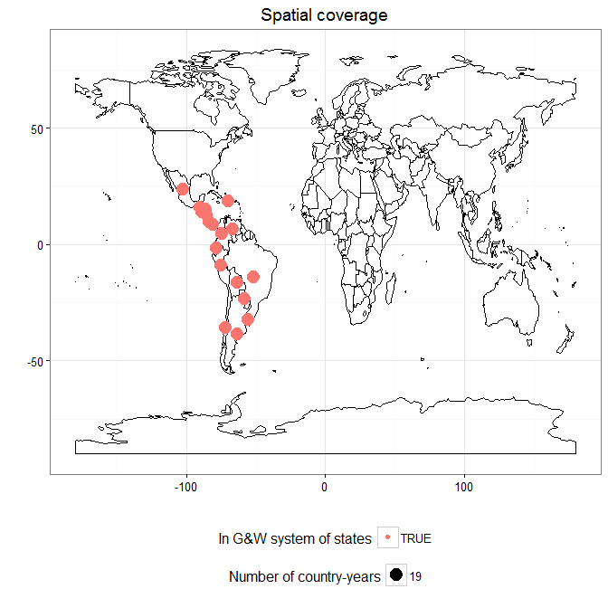

## Distribution

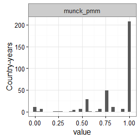

```r
ggplot(data = data) +
  geom_histogram(aes(x=value)) +
  theme_bw() +
  theme(legend.position = "bottom") +
  labs(y = "Country-years") +
  facet_wrap(~variable, ncol=2)
```

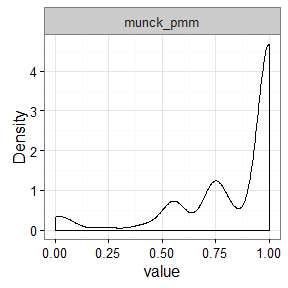

```r
ggplot(data = data) +
  geom_density(aes(x=value)) +
  theme_bw() +
  theme(legend.position = "bottom") +
  labs(y = "Density") +
  facet_wrap(~variable, ncol=2)
```

# PACL/ACLP/DD

This is the dataset described in Cheibub, Gandhi, and Vreeland 2010.

## Coverage

```r
data <- democracy_long %>% filter(variable == "pacl")

temporal_coverage(data)
```

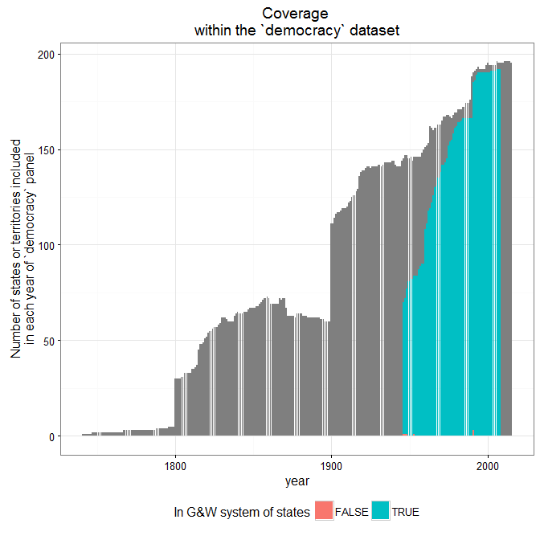

```r
spatial_coverage(data)
```

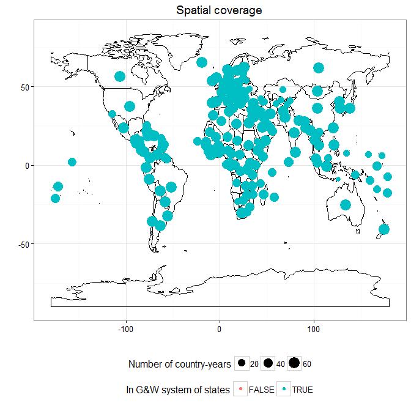

## Distribution

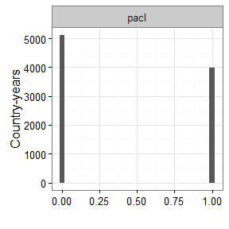

```r
ggplot(data = data) +
  geom_histogram(aes(x=value)) +
  theme_bw() +
  theme(legend.position = "bottom") +
  labs(y = "Country-years", x="") +
  facet_wrap(~variable, ncol=2)
```

# PEPS

This is the dataset described in Moon et al 2006.

## Coverage

The `democracy` file contains seven variables from this dataset: `PEPS1i`, `PEPS2i`, `PEPS1q`, `PEPS2q`, `PEPS1v`,`PEPS2v`, and `Polity3`, a cleaned up version of the `polity2` variable in the Polity IV data. The `PEPS*` variables are constructed from `Polity3` and a participation variable derived either from Vanhanen’s population and raw participation data (variables ending in `*v`) or from voting turnout data from IDEA (variables ending in `q` or `i`).

```r
data <- democracy_long %>% filter(variable %in% c("PEPS1i","PEPS2i","PEPS1q","PEPS2q","PEPS1v","PEPS2v","Polity3"))

data <- left_join(panel,data)
```

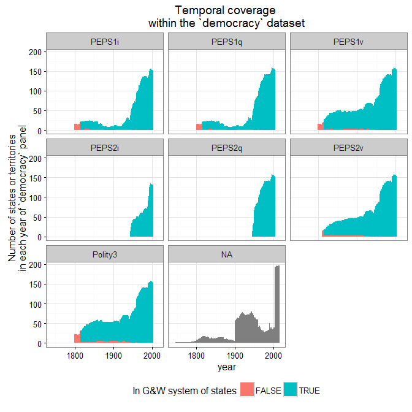

```r
data <- data %>% group_by(variable,year, add=TRUE) %>% count_(vars = c("year","in_system","variable"))

ggplot(data =  data, aes(x=year,fill = in_system, y = n)) +
    geom_bar(stat = "identity") +
    theme_bw() +
    theme(legend.position = "bottom") +
    labs(fill = "In G&W system of states", y = "Number of states or territories\nin each year of `democracy` panel") +
    ggtitle("Temporal coverage \nwithin the `democracy` dataset") +
  facet_wrap(~variable)
```

```r
data <- democracy_long %>% filter(variable %in% c("PEPS1i","PEPS2i","PEPS1q","PEPS2q","PEPS1v","PEPS2v"))

spatial_coverage(data)
```

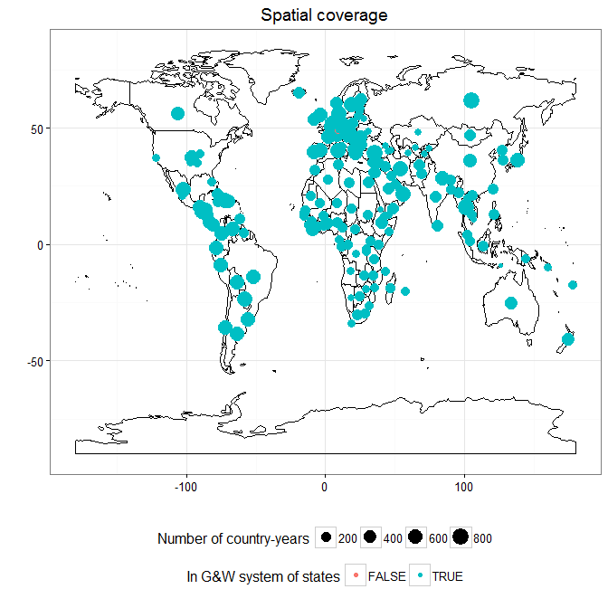

## Distribution

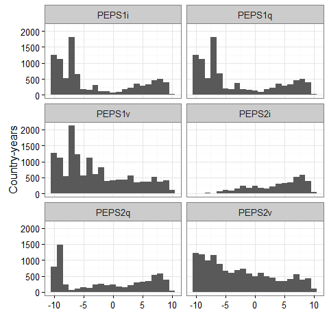

```r
ggplot(data = data) +
  geom_histogram(aes(x=value),binwidth=1) +
  theme_bw() +
  theme(legend.position = "bottom") +
  labs(y = "Country-years", x="") +
  facet_wrap(~variable, ncol=2)
```

```r
library(GGally)
ggcorr(data = democracy %>% select(PEPS1i:PEPS2v), label=TRUE,label_round=3) + scale_fill_gradient2(midpoint = 0.7)
```

```
## which will replace the existing scale.
```

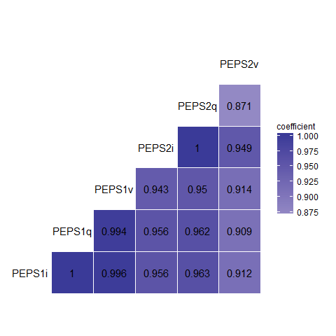

## Known problems

The `Polity3` variable is different from the `polity2` variable in the following cases, mostly due to the different way in which Moon et al recode transitional periods, but in some cases due to revisions in the underlying Polity IV dataset since 2006:

```r
kable(democracy %>%
        filter(Polity3 != polity2) %>%
        group_by(country_name,Polity3,polity2,polity) %>%
        summarise(years = min(year), max = max(year), n = n()))
```

| country_name | Polity3 | polity2 | polity | years | max | n |
| --- | --- | --- | --- | --- | --- | --- |
| Afghanistan | -7 | 0 | -77 | 1978 | 1978 | 1 |
| Albania | -9 | -5 | -88 | 1945 | 1945 | 1 |
| Albania | -9 | 0 | -77 | 1939 | 1944 | 6 |
| Angola | -6 | -3 | -88 | 1991 | 1991 | 1 |
| Angola | -5 | -1 | -88 | 1993 | 1994 | 2 |
| Angola | -4 | -2 | -88 | 1995 | 1996 | 2 |
| Angola | -3 | -2 | -2 | 2002 | 2003 | 2 |
| Argentina | -4 | -3 | -88 | 1956 | 1956 | 1 |
| Austria | 0 | -1 | -88 | 1933 | 1933 | 1 |
| Austria | 8 | 5 | -88 | 1945 | 1945 | 1 |
| Bhutan | -8 | -10 | -10 | 1953 | 2003 | 51 |
| Bolivia | -5 | -4 | -88 | 1952 | 1952 | 1 |
| Bolivia | -3 | -4 | -88 | 1955 | 1955 | 1 |
| Botswana | 7 | 6 | 6 | 1969 | 1986 | 18 |
| Botswana | 8 | 7 | 7 | 1987 | 1996 | 10 |
| Botswana | 9 | 8 | 8 | 1997 | 2003 | 7 |
| Brazil | -5 | -6 | -88 | 1932 | 1932 | 1 |
| Bulgaria | -8 | -2 | -88 | 1944 | 1944 | 1 |
| Bulgaria | -7 | -4 | -88 | 1945 | 1945 | 1 |
| Bulgaria | -6 | -7 | -88 | 1934 | 1934 | 1 |
| Burundi | -7 | -3 | -88 | 1992 | 1992 | 1 |
| Cambodia (Kampuchea) | -8 | -7 | -88 | 1970 | 1970 | 1 |
| Cambodia (Kampuchea) | -2 | 0 | -88 | 1988 | 1988 | 1 |
| Cambodia (Kampuchea) | -1 | 0 | -88 | 1989 | 1989 | 1 |
| Cambodia (Kampuchea) | -1 | 1 | -88 | 1990 | 1990 | 1 |
| Cambodia (Kampuchea) | 0 | 1 | -88 | 1991 | 1992 | 2 |
| Chad | -7 | -4 | -88 | 1984 | 1984 | 1 |
| Chad | -7 | -3 | -88 | 1978 | 1978 | 1 |
| Chad | -7 | 0 | -77 | 1979 | 1983 | 5 |
| Chile | 1 | 0 | -88 | 1924 | 1924 | 1 |

[output cut: 98 more lines]

# PITF

These are the scores used in Goldstone et al 2010 and (in binary form) in Taylor and Ulfelder 2015.

## Coverage

```r
data <- democracy_long %>% filter(variable == "pitf")

temporal_coverage(data)
```

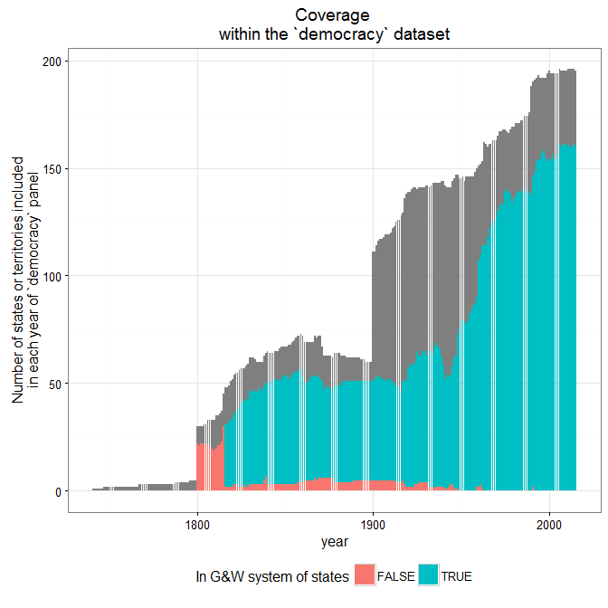

```r
spatial_coverage(data)
```

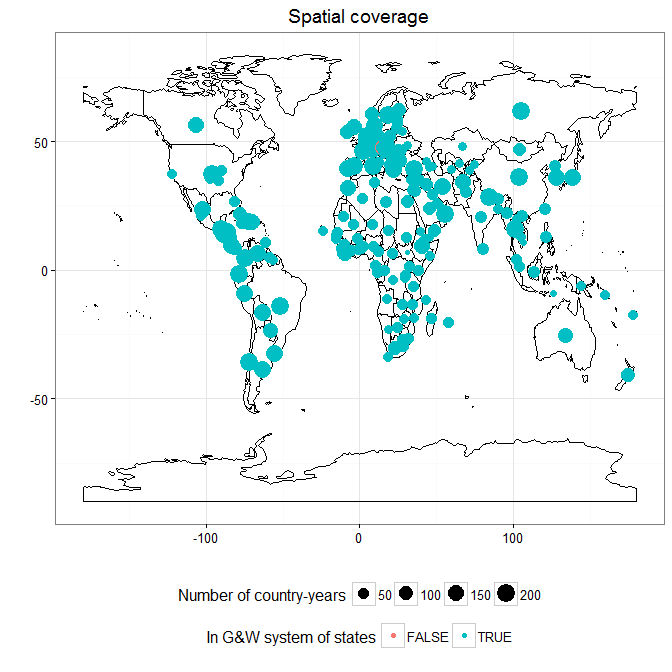